# Week 3 - Homework

STAT 420, Summer 2021, Ashutosh Agarwal (aa61)

06/06/2021

# Directions

Students are encouraged to work together on homework. However, sharing, copying or providing any part of a homework solution or code is an infraction of the University’s rules on Academic Integrity. Any violation will be punished as severely as possible.

- Be sure to remove this section if you use this `.Rmd` file as a template.
- You may leave the questions in your final document.

## Exercise 1 (Using `lm` for Inference)

For this exercise we will use the `cats` dataset from the `MASS` package. You should use `?cats` to learn about the background of this dataset.

**(a)** Fit the following simple linear regression model in `R`. Use heart weight as the response and body weight as the predictor.

$$Y_i = \beta_0 + \beta_1 x_i + \epsilon_i$$

Store the results in a variable called `cat_model`. Use a $t$ test to test the significance of the regression. Report the following:

- The null and alternative hypotheses
- The value of the test statistic
- The p-value of the test
- A statistical decision at $\alpha = 0.05$
- A conclusion in the context of the problem

When reporting these, you should explicitly state them in your document, not assume that a reader will find and interpret them from a large block of `R` output.

**Answer**

- **Null hypothesis:** $H_0$: $\beta_1$ = 0 i.e. There is no significant linear relationship between predictor (body weight) and response (Heart weight).
- **Alternate hypothesis:** $H_1$: $\beta_1$ $\neq$ 0 i.e. There is significant linear relationship between body weight and heart weight.

```r
library("MASS")
cats_model = lm(Hwt ~ Bwt, data = cats)
```

- **$t-Value$**

```r
summary(cats_model)$coefficients["Bwt", "t value"]
```

```
## [1] 16.11939
```

- **$p-value$**

```r
p_value = summary(cats_model)$coefficients["Bwt", "Pr(>|t|)"]
p_value
```

```
## [1] 6.969045e-34
```

With this extremely low p-value we can reject null hypotheses at any reasonable value of $\alpha$ .

- **Testing null hypotheses at $\alpha = 0.05$**

  There are two ways of testing this:
  - **Using value of $\alpha$ and $p-value$** We can see that $\alpha$ = $0.05$ is greater than p-value (6.9690446^{-34}). Therefore we can reject null hypotheses.
  - **Using confidence interval.**

```r
confint(object = cats_model, parm = "Bwt", level = 0.95)
```

```
##        2.5 %   97.5 %
## Bwt 3.539343 4.528782
```

Clearly $0$ is not within this range. We can reject null hypotheses for $\alpha = 0.05$

- **Conclusion** - For cats dataset, with extremely low p-value for $H_0$ = $0$ vs $H_1$ $\neq$ $0$ we can reject null hypotheses for any reasonable value of $\alpha$

In other words we can say there is significant linear relationship between Body weight and heart weight of cats.

**(b)** Calculate a 95% confidence interval for $\beta_1$. Give an interpretation of the interval in the context of the problem.

**Answer**

```r
cInt = confint(object = cats_model, parm = "Bwt", level = 0.95)
cInt
```

```
##        2.5 %   97.5 %
## Bwt 3.539343 4.528782
```

This means we are 95% confident that the true change in mean heart weight for an increase in body weight of one kg is between 3.539343 and 4.5287824

**(c)** Calculate a 90% confidence interval for $\beta_0$. Give an interpretation of the interval in the context of the problem.

**Answer**

```r
cInt = confint(object = cats_model, parm = "(Intercept)", level = 0.90)
cInt
```

```
##                   5 %      95 %
## (Intercept) -1.502834 0.7895096
```

This means we are 90% confident that the true value of heart weight when body weight is zero kg is between -1.5028345 and 0.7895096

**(d)** Use a 90% confidence interval to estimate the mean heart weight for body weights of 2.1 and 2.8 kilograms. Which of the two intervals is wider? Why?

```r
newdata = data.frame(Bwt = c(2.1, 2.8))
p = predict(object = cats_model, newdata = newdata, level = 0.9, interval = c("confidence"))
range = data.frame(range = c(p[1, "upr"] - p [1, "lwr"], p[2, "upr"] - p [2, "lwr"]))
cbind(p, range = range, Bwt = newdata)
```

```
##         fit       lwr       upr     range Bwt
## 1  8.114869  7.787882  8.441856 0.6539740 2.1
## 2 10.938713 10.735843 11.141583 0.4057402 2.8
```

Interval at 2.1 kg is wider than 2.8 kg. This is because 2.1 kg is further from the mean (of Bwt) of entire dataset 2.7236111 than 2.8 kg. And we saw in the lecture that confidence and prediction intervals are wider away from mean.

**(e)** Use a 90% prediction interval to predict the heart weight for body weights of 2.8 and 4.2 kilograms.

```r
newdata = data.frame(Bwt = c(2.8, 4.2))
p = predict(object = cats_model, newdata = newdata, level = 0.9, interval = c("prediction"))
cbind(p, Bwt = newdata)
```

```
##        fit       lwr      upr Bwt
## 1 10.93871  8.525541 13.35189 2.8
## 2 16.58640 14.097100 19.07570 4.2
```

**(f)** Create a scatterplot of the data. Add the regression line, 95% confidence bands, and 95% prediction bands.

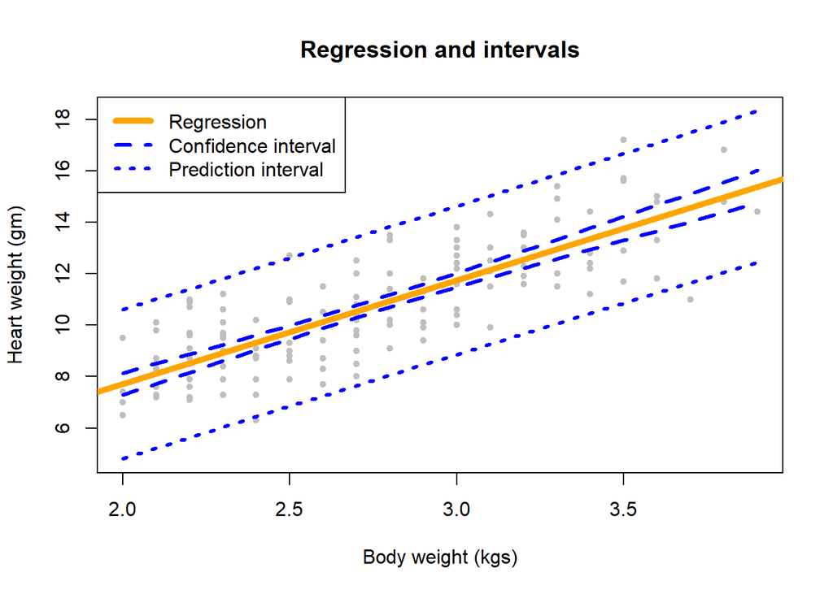

```r
beta_0_hat = cats_model$coefficients["(Intercept)"]
beta_1_hat = cats_model$coefficients["Bwt"]

newdata = data.frame(Bwt = seq(min(cats$Bwt), max(cats$Bwt), 0.1))
conf = predict(cats_model, newdata = newdata, level = 0.95, interval = c("confidence"))
pred = predict(cats_model, newdata = newdata, level = 0.95, interval = c("prediction"))

plot(Hwt ~ Bwt,
     data = cats,
     xlab = "Body weight (kgs)",
     ylab = "Heart weight (gm)",
     main = "Regression and intervals",
     col = "grey",
     pch = 20,
     ylim = c(min(pred), max(pred)))

abline(beta_0_hat, beta_1_hat, col = "Orange", lwd = 5, lty = 1)
lines(newdata$Bwt, conf[,"lwr"], col = "blue", lwd = 3,  lty = 2)
lines(newdata$Bwt, conf[,"upr"], col = "blue", lwd = 3,  lty = 2)
lines(newdata$Bwt, pred[,"lwr"], col = "blue", lwd = 3,  lty = 3)
lines(newdata$Bwt, pred[,"upr"], col = "blue", lwd = 3,  lty = 3)
legend("topleft", legend=c("Regression", "Confidence interval", "Prediction interval"), col=c("orange", "blue", "blue"), lty = 1:3, lwd = c(5,3,3))
```

**(g)** Use a $t$ test to test:

- $H_0: \beta_1 = 4$
- $H_1: \beta_1 \neq 4$

Report the following:

- The value of the test statistic
- The p-value of the test
- A statistical decision at $\alpha = 0.05$

When reporting these, you should explicitly state them in your document, not assume that a reader will find and interpret them from a large block of `R` output.

**$t-value$**

```r
beta_hat_1 = summary(cats_model)$coefficients["Bwt", "Estimate"]
beta_1 = 4

# Standard error of beta_1 is calculated as "(Residual standard error) / sqrt(Sxx)". Here RSE is std dev of errors in predictions.
# This value is also available in summary of model against Estimated of Bwt
se_beta_1 = summary(cats_model)$coefficients["Bwt", "Std. Error"]
t_value = (beta_hat_1 - beta_1)/ se_beta_1
t_value
```

```
## [1] 0.1361084
```

**$p-value$**

```r
p_value = 2 * pt(t_value, df = length(cats$Bwt) - 2, lower.tail = FALSE)
p_value
```

```
## [1] 0.8919283
```

## Exercise 2 (More `lm` for Inference)

For this exercise we will use the `Ozone` dataset from the `mlbench` package. You should use `?Ozone` to learn about the background of this dataset. You may need to install the `mlbench` package. If you do so, do not include code to install the package in your `R` Markdown document.

For simplicity, we will re-perform the data cleaning done in the previous homework.

```r
data(Ozone, package = "mlbench")
Ozone = Ozone[, c(4, 6, 7, 8)]
colnames(Ozone) = c("ozone", "wind", "humidity", "temp")
Ozone = Ozone[complete.cases(Ozone), ]
```

**(a)** Fit the following simple linear regression model in `R`. Use the ozone measurement as the response and wind speed as the predictor.

$$Y_i = \beta_0 + \beta_1 x_i + \epsilon_i$$

Store the results in a variable called `ozone_wind_model`. Use a $t$ test to test the significance of the regression. Report the following:

- The null and alternative hypotheses
- The value of the test statistic
- The p-value of the test
- A statistical decision at $\alpha = 0.01$
- A conclusion in the context of the problem

When reporting these, you should explicitly state them in your document, not assume that a reader will find and interpret them from a large block of `R` output.

**Answer**

- **Null hypothesis:** $H_0$: $\beta_1$ = $0$ i.e. There is no significant linear relationship between predictor (wind speed) and response (Ozone).
- **Alternate hypothesis:** $H_1$: $\beta_1$ $\neq$ $0$ i.e. There is significant linear relationship between wind speed and Ozone.

```r
ozone_wind_model = lm(ozone ~ wind, data = Ozone)
```

- **$t-Value$**

```r
summary(ozone_wind_model)$coefficients["wind", "t value"]
```

```
## [1] -0.2189811
```

- **$p-value$**

```r
summary(ozone_wind_model)$coefficients["wind", "Pr(>|t|)"]
```

```
## [1] 0.8267954
```

- **Testing null hypothesis at $\alpha = 0.01$**

  There are two ways of testing this:
  - **Using value of $\alpha$ and $p-value$** We can see that $\alpha$ = $0.01$ is smaller than p-value. Therefore we fail to reject null hypothesis at $\alpha$ = $0.01$.
  - **Using confidence interval.**

```r
confint(object = ozone_wind_model, parm = "wind", level = 0.99)
```

```
##           0.5 %   99.5 %
## wind -0.5709047 0.481901
```

Clearly $0$ is within this range. We fail to reject null hypothesis for $\alpha = 0.01$

- **Conclusion** - For Ozone dataset, we can say there is no significant linear relationship between wind speed and ozone.

**(b)** Fit the following simple linear regression model in `R`. Use the ozone measurement as the response and temperature as the predictor.

$$Y_i = \beta_0 + \beta_1 x_i + \epsilon_i$$

Store the results in a variable called `ozone_temp_model`. Use a $t$ test to test the significance of the regression. Report the following:

- The null and alternative hypotheses
- The value of the test statistic
- The p-value of the test
- A statistical decision at $\alpha = 0.01$
- A conclusion in the context of the problem

When reporting these, you should explicitly state them in your document, not assume that a reader will find and interpret them from a large block of `R` output.

**Answer**

- **Null hypothesis:** $H_0$: $\beta_1$ = $0$ i.e. There is no significant linear relationship between predictor (temperature) and response (Ozone).
- **Alternate hypothesis:** $H_1$: $\beta_1$ $\neq$ $0$ i.e. There is significant linear relationship between temperature and Ozone.

```r
ozone_temp_model = lm(ozone ~ temp, data = Ozone)
```

- **$t-Value$**

```r
summary(ozone_temp_model)$coefficients["temp", "t value"]
```

```
## [1] 22.84896
```

- **$p-value$**

```r
summary(ozone_temp_model)$coefficients["temp", "Pr(>|t|)"]
```

```
## [1] 8.153764e-71
```

- **Testing null hypotheses at $\alpha = 0.01$**

  There are two ways of testing this:
  - **Using value of $\alpha$ and $p-value$** We can see that $\alpha$ = $0.01$ is greater than p-value. Therefore we reject null hypothesis at $\alpha$ = $0.01$.
  - **Using confidence interval.**

```r
confint(object = ozone_temp_model, parm = "temp", level = 0.99)
```

```
##          0.5 %    99.5 %
## temp 0.3809678 0.4783891
```

Clearly $0$ is not within this range. We reject null hypothesis for $\alpha = 0.01$

- **Conclusion** - For Ozone dataset, we can say there is significant linear relationship between temperature and ozone.

## Exercise 3 (Simulating Sampling Distributions)

For this exercise we will simulate data from the following model:

$$Y_i = \beta_0 + \beta_1 x_i + \epsilon_i$$

Where $\epsilon_i \sim N(0, \sigma^2).$ Also, the parameters are known to be:

- $\beta_0 = -5$
- $\beta_1 = 3.25$
- $\sigma^2 = 16$

We will use samples of size $n = 50$.

**(a)** Simulate this model $2000$ times. Each time use `lm()` to fit a simple linear regression model, then store the value of $\hat{\beta}_0$ and $\hat{\beta}_1$. Set a seed using **your** birthday before performing the simulation. Note, we are simulating the $x$ values once, and then they remain fixed for the remainder of the exercise.

**Answer**

```r
birthday = 18691002
set.seed(birthday)
n = 50
x = seq(0, 10, length = n)
```

```r
simCount = 2000
beta_0 = -5
beta_1 = 3.25
var = 16

beta_0_hats = rep(0, simCount)
beta_1_hats = rep(0, simCount)

for (i in 1:simCount){
  eps = rnorm(n = n, mean = 0, sd = sqrt(var))
  y = beta_0 + beta_1 * x + eps
  model = lm(y ~ x)

  beta_0_hats[i] = coef(model)[1]
  beta_1_hats[i] = coef(model)[2]
}
```

**(b)** Create a table that summarizes the results of the simulations. The table should have two columns, one for $\hat{\beta}_0$ and one for $\hat{\beta}_1$. The table should have four rows:

- A row for the true expected value given the known values of $x$
- A row for the mean of the simulated values
- A row for the true standard deviation given the known values of $x$
- A row for the standard deviation of the simulated values

**Answer**

```r
Sxx = sum((x - mean(x)) ^ 2)
var_true_beta_1_hats = var / Sxx
var_true_beta_0_hats = var * (1/ n + (mean(x) ^ 2)/ Sxx)

beta_0_summary = c(beta_0, mean(beta_0_hats), sqrt(var_true_beta_0_hats), sd(beta_0_hats))
beta_1_summary = c(beta_1, mean(beta_1_hats), sqrt(var_true_beta_1_hats), sd(beta_1_hats))
sim_summary = data.frame(beta_0_summary, beta_1_summary)

colnames(sim_summary) = c("beta_0_hat", "beta_1_hat")
rownames(sim_summary) = c("True expected", "Simulation mean", "True Std Dev", "Simulation Sd")

library(knitr)
kable(x = sim_summary, align = 'c')
```

|  | beta_0_hat | beta_1_hat |
| --- | --- | --- |
| True expected | -5.000000 | 3.2500000 |
| Simulation mean | -4.999761 | 3.2495027 |
| True Std Dev | 1.114609 | 0.1920784 |
| Simulation Sd | 1.130309 | 0.1941843 |

**(c)** Plot two histograms side-by-side:

- A histogram of your simulated values for $\hat{\beta}_0$. Add the normal curve for the true sampling distribution of $\hat{\beta}_0$.
- A histogram of your simulated values for $\hat{\beta}_1$. Add the normal curve for the true sampling distribution of $\hat{\beta}_1$.

**Answer**

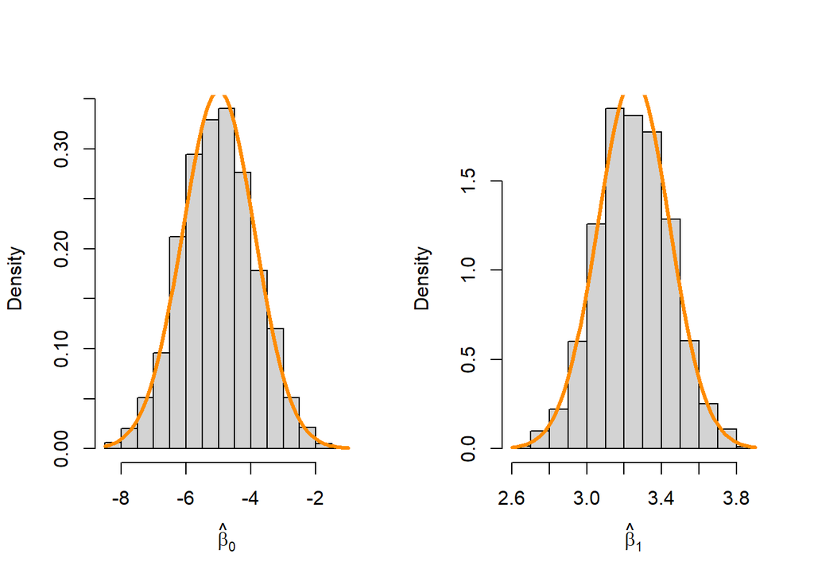

```r
par(mfrow=c(1,2))
hist(beta_0_hats, main = "", prob = TRUE, xlab = expression(hat(beta)[0]))
curve(dnorm(x, mean = beta_0, sd = sqrt(var_true_beta_0_hats)), col = "darkorange", add = TRUE, lwd = 3)

hist(beta_1_hats, main = "", prob = TRUE, xlab = expression(hat(beta)[1]))
curve(dnorm(x, mean = beta_1, sd = sqrt(var_true_beta_1_hats)), col = "darkorange", add = TRUE, lwd = 3)
```

## Exercise 4 (Simulating Confidence Intervals)

For this exercise we will simulate data from the following model:

$$Y_i = \beta_0 + \beta_1 x_i + \epsilon_i$$

Where $\epsilon_i \sim N(0, \sigma^2).$ Also, the parameters are known to be:

- $\beta_0 = 5$
- $\beta_1 = 2$
- $\sigma^2 = 9$

We will use samples of size $n = 25$.

Our goal here is to use simulation to verify that the confidence intervals really do have their stated confidence level. Do **not** use the `confint()` function for this entire exercise.

**(a)** Simulate this model $2500$ times. Each time use `lm()` to fit a simple linear regression model, then store the value of $\hat{\beta}_1$ and $s_e$. Set a seed using **your** birthday before performing the simulation. Note, we are simulating the $x$ values once, and then they remain fixed for the remainder of the exercise.

```r
birthday = 18691002
set.seed(birthday)
n = 25
x = seq(0, 2.5, length = n)
```

```r
simCount = 2500
beta_0 = 5
beta_1 = 2
var = 9

s_es = rep(0, simCount)
beta_1_hats = rep(0, simCount)

for (i in 1:simCount){
  eps = rnorm(n = n, mean = 0, sd = sqrt(var))
  y = beta_0 + beta_1 * x + eps
  model = lm(y ~ x)

  # Note for myself: Std error against predictor in summary(model) is "Residual error of predictions / sqrt(Sxx)"
  # Had we stored std error of beta_1 then we would not have to calculate Sxx in the conf interval calculation.
  # s_es[i] = summary(model)$coefficients["x", "Std. Error"]

  s_es[i] = summary(model)$sigma
  beta_1_hats[i] = coef(model)[2]
}
```

**(b)** For each of the $\hat{\beta}_1$ that you simulated, calculate a 95% confidence interval. Store the lower limits in a vector `lower_95` and the upper limits in a vector `upper_95`. Some hints:

- You will need to use `qt()` to calculate the critical value, which will be the same for each interval.
- Remember that `x` is fixed, so $S_{xx}$ will be the same for each interval.
- You could, but do not need to write a `for` loop. Remember vectorized operations.

```r
Sxx = sum((x - mean(x))^2)
crit = qt(p = 0.975, df = n -2)

# Note: We actually did not need to use Sxx if we had stored standard errors of beta_1 instead
lower_95 = beta_1_hats - crit * s_es / sqrt(Sxx)
upper_95 = beta_1_hats + crit * s_es / sqrt(Sxx)
```

**(c)** What proportion of these intervals contains the true value of $\beta_1$?

**Answer:**

```r
mean(beta_1 >= lower_95 & beta_1 <= upper_95)
```

```
## [1] 0.9528
```

**(d)** Based on these intervals, what proportion of the simulations would reject the test $H_0: \beta_1 = 0$ vs $H_1: \beta_1 \neq 0$ at $\alpha = 0.05$?

**Answer:**

```r
1 - mean(0 >= lower_95 & 0 <= upper_95)
```

```
## [1] 0.68
```

The proportion of simulations in which we will reject the null hypotheses is 0.68 because $0$ is not included within 95% confidence interval of these simulations.

**(e)** For each of the $\hat{\beta}_1$ that you simulated, calculate a 99% confidence interval. Store the lower limits in a vector `lower_99` and the upper limits in a vector `upper_99`.

```r
crit = qt(p = 0.995, df = n -2)

# Note: We actually did not need to use Sxx if we had stored standard errors of beta_1 instead
lower_99 = beta_1_hats - crit * s_es / sqrt(Sxx)
upper_99 = beta_1_hats + crit * s_es / sqrt(Sxx)
```

**(f)** What proportion of these intervals contains the true value of $\beta_1$?

```r
mean(beta_1 >= lower_99 & beta_1 <= upper_99)
```

```
## [1] 0.9904
```

**(g)** Based on these intervals, what proportion of the simulations would reject the test $H_0: \beta_1 = 0$ vs $H_1: \beta_1 \neq 0$ at $\alpha = 0.01$?

**Answer:**

```r
1 - mean(0 >= lower_99 & 0 <= upper_99)
```

```
## [1] 0.426
```

The proportion of simulations in which we will reject the null hypotheses is 0.426 because $0$ is not included within 99% confidence interval of these simulations.

## Exercise 5 (Prediction Intervals “without” `predict`)

Write a function named `calc_pred_int` that performs calculates prediction intervals:

$$\hat{y}(x) \pm t_{\alpha/2, n - 2} \cdot s_e\sqrt{1 + \frac{1}{n}+\frac{(x-\bar{x})^2}{S_{xx}}}.$$

for the linear model

$$Y_i = \beta_0 + \beta_1 x_i + \epsilon_i.$$

**(a)** Write this function. You may use the `predict()` function, but you may **not** supply a value for the `level` argument of `predict()`. (You can certainly use `predict()` any way you would like in order to check your work.)

The function should take three inputs:

- `model`, a model object that is the result of fitting the SLR model with `lm()`
- `newdata`, a data frame with a single observation (row)
  - This data frame will need to have a variable (column) with the same name as the data used to fit `model`.
- `level`, the level (0.90, 0.95, etc) for the interval with a default value of `0.95`

The function should return a named vector with three elements:

- `estimate`, the midpoint of the interval
- `lower`, the lower bound of the interval
- `upper`, the upper bound of the interval

```r
calc_pred_int = function(model, newdata, level = 0.95){
  n = nrow(model$model)

  y_hat = predict(model, newdata = newdata)
  crit = qt(p = level + (1 - level)/2, df = n - 2)

  predictorName = colnames(newdata)[1]

  # We cannot calculate mean over data frame, therefore we are converting it to a vector.
  # it would be simpler if we could use name of column directly
  x = as.double(model$model[,predictorName])

  Sxx = sum((x-mean(x))^2)

  # Note that we need standard error of x not beta_0 or beta_1
  s_e = summary(model)$sigma

  margin = crit * s_e * sqrt(1 + 1/ n + ((newdata - mean(x))^2) / Sxx)

  c(estimate = y_hat, lower = y_hat - margin, upper = y_hat + margin)
}
```

**(b)** After writing the function, run this code:

```r
newcat_1 = data.frame(Bwt = 4.0)
calc_pred_int(cats_model, newcat_1)
```

```
## $estimate.1
## [1] 15.77959
##
## $lower.Bwt
## [1] 12.83018
##
## $upper.Bwt
## [1] 18.729
```

```r
# Verifying if output is consistent with Predict method

predict(object = cats_model, newdata = newcat_1, level = 0.95, interval = c("prediction"))
```

```
##        fit      lwr    upr
## 1 15.77959 12.83018 18.729
```

**(c)** After writing the function, run this code:

```r
newcat_2 = data.frame(Bwt = 3.3)
calc_pred_int(cats_model, newcat_2, level = 0.90)
```

```
## $estimate.1
## [1] 12.95574
##
## $lower.Bwt
## [1] 10.53099
##
## $upper.Bwt
## [1] 15.3805
```

```r
# Verifying if output is consistent with Predict method

predict(object = cats_model, newdata = newcat_2, level = 0.90, interval = c("prediction"))
```

```
##        fit      lwr     upr
## 1 12.95574 10.53099 15.3805
```